# Assignment 2

Jean Clipperton

2025-06-12

## Assignment 2

This is an example file – note that this is a MINIMAL version. We are providing an example of a possible version of the assignment here to give you a sense of expectations.

## Explore the data

We are using a sample of GSS data. To learn more, [see this dataset description here](https://r-packages.io/datasets/gss_wages).

### Very specific questions

1. Load and describe the dataframe ‘gss_wages’

```
##             vars     n     mean       sd median  trimmed      mad  min      max
## year           1 61697  1996.07    12.79   1996  1996.09    14.83 1974   2018.0
## realrinc       2 37887 22326.36 28581.79  16563 17823.94 13605.82  227 480144.5
## age            3 61478    46.18    17.56     44    45.18    20.76   18     89.0
## occ10          4 58136  4695.77  2627.72   4720  4666.45  2386.99   10   9997.0
## occrecode*     5 58136     6.97     2.77      8     7.16     2.97    1     11.0
## prestg10       6 57511    43.06    12.99     42    42.40    11.86   16     80.0
## childs         7 61508     1.92     1.76      2     1.70     1.48    0      8.0
## wrkstat*       8 61676     2.60     2.03      2     2.28     1.48    1      8.0
## gender*        9 61697     1.44     0.50      1     1.42     0.00    1      2.0
## educcat*      10 61562     3.09     1.24      3     3.11     0.00    1      5.0
## maritalcat*   11 61670     2.44     1.08      2     2.31     0.00    1      5.0
##                range  skew kurtosis     se
## year            44.0  0.00    -1.11   0.05
## realrinc    479917.5  6.79    77.96 146.84
## age             71.0  0.42    -0.77   0.07
## occ10         9987.0  0.09    -0.69  10.90
## occrecode*      10.0 -0.58    -0.68   0.01
## prestg10        64.0  0.44    -0.40   0.05
## childs           8.0  1.02     1.11   0.01
## wrkstat*         7.0  1.03    -0.07   0.01
## gender*          1.0  0.24    -1.94   0.00
## educcat*         4.0  0.00    -0.57   0.00
## maritalcat*      4.0  1.06     0.66   0.00
```

1. Generate a data frame that summarizes the number of women and men per education category Print the data frame as a formatted `kable()` table.

Number of Women and Men per Education Category

| educcat | Female | Male |
| --- | --- | --- |
| Bachelor | 4878 | 4341 |
| Graduate | 2217 | 2382 |
| High School | 18238 | 13475 |
| Junior College | 2154 | 1477 |
| Less Than High School | 7025 | 5375 |
| NA | 79 | 56 |

1. Generate a boxplot visualizing the wages of individuals, by recoded occupational category.

[figure not shown]

1. Generate a bar chart that identifies the total number of children by each education category. The bars should be sorted from highest to lowest.

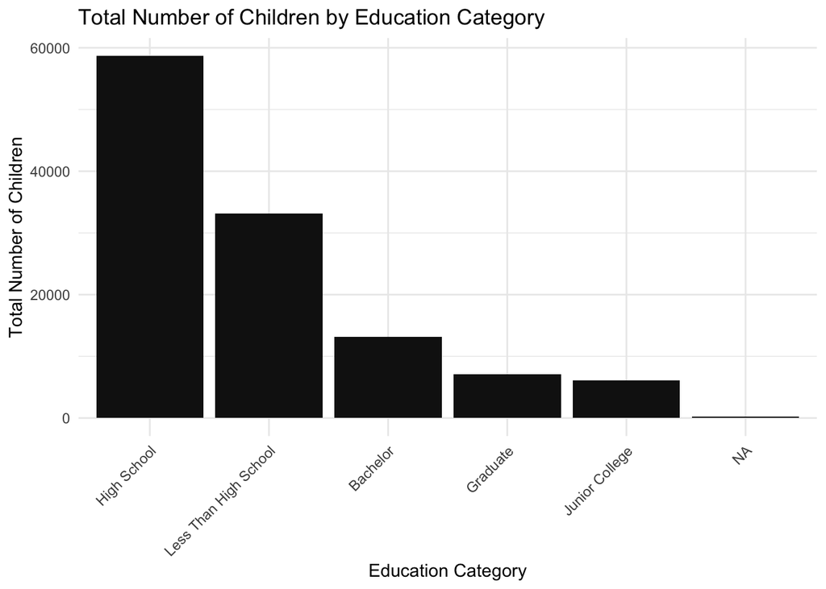

### More open-ended questions

Answer the following questions. Generate appropriate figures/tables to support your conclusions.

1. How many women and how many men have a high school education?

[figure not shown]

[output not shown]

### Very open-ended questions

Answer the following questions. Generate appropriate figures/tables to support your conclusions. Provide 1-2 paragraphs of written interpretation of your results for each question. Graphs and/or tables alone will not be sufficient to answer these questions. You will be graded on your code and your analysis.

1. We generated total number of children by category. Is this helpful to understand the question of whether people with different educational backgrounds have more children? Explain why or why not, and include any supplemental visualizations you wish.
2. Consider the findings regarding income and occupation. What additional variable might you use to help you uncover any additional underlying trends? Be specific and provide additional visualizations and/or tables as needed.

### AI / Resources statement.

All assignments need about one paragraph describing the resources you used (including links and prompts, as relevant) in completing the assignment. This helps us learn about your process. Include this in your assignment submission.

**sample response** *I used ChatGPT on the question to separate by gender because I kept getting an error about splitting by group. I realized that I had missed summarizing by gender. I also googled to find a suitable theme for the markdown file*